# Risk Factor Analysis

## Outcome Variable

**Outcome Variable:** ever_stunted

## Predictor Variables

**Intervention Variable:** born_stunted

**Adjustment Set:**

unadjusted

## Stratifying Variables

The analysis was stratified on these variable(s):

- agecat
- studyid
- country

## Data Summary

| agecat | studyid | country | born_stunted | ever_stunted | n_cell | n |
| --- | --- | --- | --- | --- | --- | --- |
| 0-3 months | ki0047075b-MAL-ED | BANGLADESH | 0 | 0 | 184 | 244 |
| 0-3 months | ki0047075b-MAL-ED | BANGLADESH | 0 | 1 | 28 | 244 |
| 0-3 months | ki0047075b-MAL-ED | BANGLADESH | 1 | 0 | 32 | 244 |
| 0-3 months | ki0047075b-MAL-ED | BANGLADESH | 1 | 1 | 0 | 244 |
| 0-3 months | ki0047075b-MAL-ED | BRAZIL | 0 | 0 | 156 | 183 |
| 0-3 months | ki0047075b-MAL-ED | BRAZIL | 0 | 1 | 13 | 183 |
| 0-3 months | ki0047075b-MAL-ED | BRAZIL | 1 | 0 | 14 | 183 |
| 0-3 months | ki0047075b-MAL-ED | BRAZIL | 1 | 1 | 0 | 183 |
| 0-3 months | ki0047075b-MAL-ED | INDIA | 0 | 0 | 151 | 204 |
| 0-3 months | ki0047075b-MAL-ED | INDIA | 0 | 1 | 23 | 204 |
| 0-3 months | ki0047075b-MAL-ED | INDIA | 1 | 0 | 30 | 204 |
| 0-3 months | ki0047075b-MAL-ED | INDIA | 1 | 1 | 0 | 204 |
| 0-3 months | ki0047075b-MAL-ED | NEPAL | 0 | 0 | 147 | 168 |
| 0-3 months | ki0047075b-MAL-ED | NEPAL | 0 | 1 | 7 | 168 |
| 0-3 months | ki0047075b-MAL-ED | NEPAL | 1 | 0 | 14 | 168 |
| 0-3 months | ki0047075b-MAL-ED | NEPAL | 1 | 1 | 0 | 168 |
| 0-3 months | ki0047075b-MAL-ED | PERU | 0 | 0 | 195 | 282 |
| 0-3 months | ki0047075b-MAL-ED | PERU | 0 | 1 | 61 | 282 |
| 0-3 months | ki0047075b-MAL-ED | PERU | 1 | 0 | 26 | 282 |
| 0-3 months | ki0047075b-MAL-ED | PERU | 1 | 1 | 0 | 282 |
| 0-3 months | ki0047075b-MAL-ED | SOUTH AFRICA | 0 | 0 | 192 | 258 |
| 0-3 months | ki0047075b-MAL-ED | SOUTH AFRICA | 0 | 1 | 40 | 258 |
| 0-3 months | ki0047075b-MAL-ED | SOUTH AFRICA | 1 | 0 | 26 | 258 |
| 0-3 months | ki0047075b-MAL-ED | SOUTH AFRICA | 1 | 1 | 0 | 258 |
| 0-3 months | ki0047075b-MAL-ED | TANZANIA, UNITED REPUBLIC OF | 0 | 0 | 110 | 145 |
| 0-3 months | ki0047075b-MAL-ED | TANZANIA, UNITED REPUBLIC OF | 0 | 1 | 18 | 145 |
| 0-3 months | ki0047075b-MAL-ED | TANZANIA, UNITED REPUBLIC OF | 1 | 0 | 17 | 145 |
| 0-3 months | ki0047075b-MAL-ED | TANZANIA, UNITED REPUBLIC OF | 1 | 1 | 0 | 145 |
| 0-3 months | ki1000108-CMC-V-BCS-2002 | INDIA | 0 | 0 | 51 | 84 |
| 0-3 months | ki1000108-CMC-V-BCS-2002 | INDIA | 0 | 1 | 22 | 84 |

[output cut: 410 more lines]

The following strata were considered:

- agecat: 0-3 months, studyid: ki0047075b-MAL-ED, country: BANGLADESH
- agecat: 0-3 months, studyid: ki0047075b-MAL-ED, country: BRAZIL
- agecat: 0-3 months, studyid: ki0047075b-MAL-ED, country: INDIA
- agecat: 0-3 months, studyid: ki0047075b-MAL-ED, country: NEPAL
- agecat: 0-3 months, studyid: ki0047075b-MAL-ED, country: PERU
- agecat: 0-3 months, studyid: ki0047075b-MAL-ED, country: SOUTH AFRICA
- agecat: 0-3 months, studyid: ki0047075b-MAL-ED, country: TANZANIA, UNITED REPUBLIC OF
- agecat: 0-3 months, studyid: ki1000108-CMC-V-BCS-2002, country: INDIA
- agecat: 0-3 months, studyid: ki1000108-IRC, country: INDIA
- agecat: 0-3 months, studyid: ki1000109-EE, country: PAKISTAN
- agecat: 0-3 months, studyid: ki1000109-ResPak, country: PAKISTAN
- agecat: 0-3 months, studyid: ki1000304b-SAS-CompFeed, country: INDIA
- agecat: 0-3 months, studyid: ki1017093-NIH-Birth, country: BANGLADESH
- agecat: 0-3 months, studyid: ki1017093b-PROVIDE, country: BANGLADESH
- agecat: 0-3 months, studyid: ki1017093c-NIH-Crypto, country: BANGLADESH
- agecat: 0-3 months, studyid: ki1101329-Keneba, country: GAMBIA
- agecat: 0-3 months, studyid: ki1114097-CMIN, country: BANGLADESH
- agecat: 0-3 months, studyid: ki1114097-CMIN, country: BRAZIL
- agecat: 0-3 months, studyid: ki1114097-CMIN, country: GUINEA-BISSAU
- agecat: 0-3 months, studyid: ki1114097-CMIN, country: PERU
- agecat: 0-3 months, studyid: ki1114097-CONTENT, country: PERU
- agecat: 0-3 months, studyid: ki1119695-PROBIT, country: BELARUS
- agecat: 0-3 months, studyid: ki1126311-ZVITAMBO, country: ZIMBABWE
- agecat: 0-3 months, studyid: ki1135781-COHORTS, country: GUATEMALA
- agecat: 0-3 months, studyid: ki1135781-COHORTS, country: INDIA
- agecat: 0-3 months, studyid: ki1135781-COHORTS, country: PHILIPPINES
- agecat: 0-3 months, studyid: kiGH5241-JiVitA-3, country: BANGLADESH
- agecat: 0-3 months, studyid: kiGH5241-JiVitA-4, country: BANGLADESH
- agecat: 12-24 months, studyid: ki0047075b-MAL-ED, country: BANGLADESH
- agecat: 12-24 months, studyid: ki0047075b-MAL-ED, country: BRAZIL
- agecat: 12-24 months, studyid: ki0047075b-MAL-ED, country: INDIA
- agecat: 12-24 months, studyid: ki0047075b-MAL-ED, country: NEPAL
- agecat: 12-24 months, studyid: ki0047075b-MAL-ED, country: PERU
- agecat: 12-24 months, studyid: ki0047075b-MAL-ED, country: SOUTH AFRICA
- agecat: 12-24 months, studyid: ki0047075b-MAL-ED, country: TANZANIA, UNITED REPUBLIC OF
- agecat: 12-24 months, studyid: ki1000108-CMC-V-BCS-2002, country: INDIA
- agecat: 12-24 months, studyid: ki1000108-IRC, country: INDIA
- agecat: 12-24 months, studyid: ki1000109-EE, country: PAKISTAN
- agecat: 12-24 months, studyid: ki1000109-ResPak, country: PAKISTAN
- agecat: 12-24 months, studyid: ki1000304b-SAS-CompFeed, country: INDIA
- agecat: 12-24 months, studyid: ki1017093-NIH-Birth, country: BANGLADESH
- agecat: 12-24 months, studyid: ki1017093b-PROVIDE, country: BANGLADESH
- agecat: 12-24 months, studyid: ki1017093c-NIH-Crypto, country: BANGLADESH
- agecat: 12-24 months, studyid: ki1101329-Keneba, country: GAMBIA
- agecat: 12-24 months, studyid: ki1114097-CMIN, country: BANGLADESH
- agecat: 12-24 months, studyid: ki1114097-CMIN, country: BRAZIL
- agecat: 12-24 months, studyid: ki1114097-CMIN, country: GUINEA-BISSAU
- agecat: 12-24 months, studyid: ki1114097-CMIN, country: PERU
- agecat: 12-24 months, studyid: ki1114097-CONTENT, country: PERU
- agecat: 12-24 months, studyid: ki1119695-PROBIT, country: BELARUS
- agecat: 12-24 months, studyid: ki1126311-ZVITAMBO, country: ZIMBABWE
- agecat: 12-24 months, studyid: ki1135781-COHORTS, country: GUATEMALA
- agecat: 12-24 months, studyid: ki1135781-COHORTS, country: PHILIPPINES
- agecat: 12-24 months, studyid: kiGH5241-JiVitA-3, country: BANGLADESH
- agecat: 12-24 months, studyid: kiGH5241-JiVitA-4, country: BANGLADESH
- agecat: 3-6 months, studyid: ki0047075b-MAL-ED, country: BANGLADESH
- agecat: 3-6 months, studyid: ki0047075b-MAL-ED, country: BRAZIL
- agecat: 3-6 months, studyid: ki0047075b-MAL-ED, country: INDIA
- agecat: 3-6 months, studyid: ki0047075b-MAL-ED, country: NEPAL
- agecat: 3-6 months, studyid: ki0047075b-MAL-ED, country: PERU
- agecat: 3-6 months, studyid: ki0047075b-MAL-ED, country: SOUTH AFRICA
- agecat: 3-6 months, studyid: ki0047075b-MAL-ED, country: TANZANIA, UNITED REPUBLIC OF
- agecat: 3-6 months, studyid: ki1000108-CMC-V-BCS-2002, country: INDIA
- agecat: 3-6 months, studyid: ki1000108-IRC, country: INDIA
- agecat: 3-6 months, studyid: ki1000109-EE, country: PAKISTAN
- agecat: 3-6 months, studyid: ki1000109-ResPak, country: PAKISTAN
- agecat: 3-6 months, studyid: ki1000304b-SAS-CompFeed, country: INDIA
- agecat: 3-6 months, studyid: ki1017093-NIH-Birth, country: BANGLADESH
- agecat: 3-6 months, studyid: ki1017093b-PROVIDE, country: BANGLADESH
- agecat: 3-6 months, studyid: ki1017093c-NIH-Crypto, country: BANGLADESH
- agecat: 3-6 months, studyid: ki1101329-Keneba, country: GAMBIA
- agecat: 3-6 months, studyid: ki1114097-CMIN, country: BANGLADESH
- agecat: 3-6 months, studyid: ki1114097-CMIN, country: BRAZIL
- agecat: 3-6 months, studyid: ki1114097-CMIN, country: GUINEA-BISSAU
- agecat: 3-6 months, studyid: ki1114097-CMIN, country: PERU
- agecat: 3-6 months, studyid: ki1114097-CONTENT, country: PERU
- agecat: 3-6 months, studyid: ki1119695-PROBIT, country: BELARUS
- agecat: 3-6 months, studyid: ki1126311-ZVITAMBO, country: ZIMBABWE
- agecat: 3-6 months, studyid: ki1135781-COHORTS, country: GUATEMALA
- agecat: 3-6 months, studyid: ki1135781-COHORTS, country: PHILIPPINES
- agecat: 3-6 months, studyid: kiGH5241-JiVitA-3, country: BANGLADESH
- agecat: 3-6 months, studyid: kiGH5241-JiVitA-4, country: BANGLADESH
- agecat: 6-12 months, studyid: ki0047075b-MAL-ED, country: BANGLADESH
- agecat: 6-12 months, studyid: ki0047075b-MAL-ED, country: BRAZIL
- agecat: 6-12 months, studyid: ki0047075b-MAL-ED, country: INDIA
- agecat: 6-12 months, studyid: ki0047075b-MAL-ED, country: NEPAL
- agecat: 6-12 months, studyid: ki0047075b-MAL-ED, country: PERU
- agecat: 6-12 months, studyid: ki0047075b-MAL-ED, country: SOUTH AFRICA
- agecat: 6-12 months, studyid: ki0047075b-MAL-ED, country: TANZANIA, UNITED REPUBLIC OF
- agecat: 6-12 months, studyid: ki1000108-CMC-V-BCS-2002, country: INDIA
- agecat: 6-12 months, studyid: ki1000108-IRC, country: INDIA
- agecat: 6-12 months, studyid: ki1000109-EE, country: PAKISTAN
- agecat: 6-12 months, studyid: ki1000109-ResPak, country: PAKISTAN
- agecat: 6-12 months, studyid: ki1000304b-SAS-CompFeed, country: INDIA
- agecat: 6-12 months, studyid: ki1017093-NIH-Birth, country: BANGLADESH
- agecat: 6-12 months, studyid: ki1017093b-PROVIDE, country: BANGLADESH
- agecat: 6-12 months, studyid: ki1017093c-NIH-Crypto, country: BANGLADESH
- agecat: 6-12 months, studyid: ki1101329-Keneba, country: GAMBIA
- agecat: 6-12 months, studyid: ki1114097-CMIN, country: BANGLADESH
- agecat: 6-12 months, studyid: ki1114097-CMIN, country: BRAZIL
- agecat: 6-12 months, studyid: ki1114097-CMIN, country: GUINEA-BISSAU
- agecat: 6-12 months, studyid: ki1114097-CMIN, country: PERU
- agecat: 6-12 months, studyid: ki1114097-CONTENT, country: PERU
- agecat: 6-12 months, studyid: ki1119695-PROBIT, country: BELARUS
- agecat: 6-12 months, studyid: ki1126311-ZVITAMBO, country: ZIMBABWE
- agecat: 6-12 months, studyid: ki1135781-COHORTS, country: GUATEMALA
- agecat: 6-12 months, studyid: ki1135781-COHORTS, country: INDIA
- agecat: 6-12 months, studyid: ki1135781-COHORTS, country: PHILIPPINES
- agecat: 6-12 months, studyid: kiGH5241-JiVitA-3, country: BANGLADESH
- agecat: 6-12 months, studyid: kiGH5241-JiVitA-4, country: BANGLADESH

### Dropped Strata

Some strata were dropped due to rare outcomes:

- agecat: 0-3 months, studyid: ki0047075b-MAL-ED, country: BANGLADESH
- agecat: 0-3 months, studyid: ki0047075b-MAL-ED, country: BRAZIL
- agecat: 0-3 months, studyid: ki0047075b-MAL-ED, country: INDIA
- agecat: 0-3 months, studyid: ki0047075b-MAL-ED, country: NEPAL
- agecat: 0-3 months, studyid: ki0047075b-MAL-ED, country: PERU
- agecat: 0-3 months, studyid: ki0047075b-MAL-ED, country: SOUTH AFRICA
- agecat: 0-3 months, studyid: ki0047075b-MAL-ED, country: TANZANIA, UNITED REPUBLIC OF
- agecat: 0-3 months, studyid: ki1000108-CMC-V-BCS-2002, country: INDIA
- agecat: 0-3 months, studyid: ki1000108-IRC, country: INDIA
- agecat: 0-3 months, studyid: ki1000109-EE, country: PAKISTAN
- agecat: 0-3 months, studyid: ki1000109-ResPak, country: PAKISTAN
- agecat: 0-3 months, studyid: ki1000304b-SAS-CompFeed, country: INDIA
- agecat: 0-3 months, studyid: ki1017093-NIH-Birth, country: BANGLADESH
- agecat: 0-3 months, studyid: ki1017093b-PROVIDE, country: BANGLADESH
- agecat: 0-3 months, studyid: ki1017093c-NIH-Crypto, country: BANGLADESH
- agecat: 0-3 months, studyid: ki1101329-Keneba, country: GAMBIA
- agecat: 0-3 months, studyid: ki1114097-CMIN, country: BANGLADESH
- agecat: 0-3 months, studyid: ki1114097-CMIN, country: BRAZIL
- agecat: 0-3 months, studyid: ki1114097-CMIN, country: GUINEA-BISSAU
- agecat: 0-3 months, studyid: ki1114097-CMIN, country: PERU
- agecat: 0-3 months, studyid: ki1114097-CONTENT, country: PERU
- agecat: 0-3 months, studyid: ki1119695-PROBIT, country: BELARUS
- agecat: 0-3 months, studyid: ki1126311-ZVITAMBO, country: ZIMBABWE
- agecat: 0-3 months, studyid: ki1135781-COHORTS, country: GUATEMALA
- agecat: 0-3 months, studyid: ki1135781-COHORTS, country: INDIA
- agecat: 0-3 months, studyid: ki1135781-COHORTS, country: PHILIPPINES
- agecat: 0-3 months, studyid: kiGH5241-JiVitA-3, country: BANGLADESH
- agecat: 0-3 months, studyid: kiGH5241-JiVitA-4, country: BANGLADESH
- agecat: 3-6 months, studyid: ki0047075b-MAL-ED, country: BRAZIL
- agecat: 3-6 months, studyid: ki0047075b-MAL-ED, country: INDIA
- agecat: 3-6 months, studyid: ki0047075b-MAL-ED, country: NEPAL
- agecat: 3-6 months, studyid: ki0047075b-MAL-ED, country: PERU
- agecat: 3-6 months, studyid: ki0047075b-MAL-ED, country: SOUTH AFRICA
- agecat: 3-6 months, studyid: ki0047075b-MAL-ED, country: TANZANIA, UNITED REPUBLIC OF
- agecat: 3-6 months, studyid: ki1000108-CMC-V-BCS-2002, country: INDIA
- agecat: 3-6 months, studyid: ki1000108-IRC, country: INDIA
- agecat: 3-6 months, studyid: ki1000109-EE, country: PAKISTAN
- agecat: 3-6 months, studyid: ki1000109-ResPak, country: PAKISTAN
- agecat: 3-6 months, studyid: ki1017093-NIH-Birth, country: BANGLADESH
- agecat: 3-6 months, studyid: ki1017093b-PROVIDE, country: BANGLADESH
- agecat: 3-6 months, studyid: ki1114097-CMIN, country: BANGLADESH
- agecat: 3-6 months, studyid: ki1114097-CMIN, country: BRAZIL
- agecat: 3-6 months, studyid: ki1114097-CMIN, country: GUINEA-BISSAU
- agecat: 3-6 months, studyid: ki1114097-CMIN, country: PERU
- agecat: 3-6 months, studyid: ki1114097-CONTENT, country: PERU
- agecat: 3-6 months, studyid: ki1119695-PROBIT, country: BELARUS
- agecat: 3-6 months, studyid: ki1135781-COHORTS, country: GUATEMALA
- agecat: 3-6 months, studyid: kiGH5241-JiVitA-3, country: BANGLADESH
- agecat: 3-6 months, studyid: kiGH5241-JiVitA-4, country: BANGLADESH
- agecat: 6-12 months, studyid: ki0047075b-MAL-ED, country: BRAZIL
- agecat: 6-12 months, studyid: ki0047075b-MAL-ED, country: INDIA
- agecat: 6-12 months, studyid: ki0047075b-MAL-ED, country: NEPAL
- agecat: 6-12 months, studyid: ki0047075b-MAL-ED, country: SOUTH AFRICA
- agecat: 6-12 months, studyid: ki0047075b-MAL-ED, country: TANZANIA, UNITED REPUBLIC OF
- agecat: 6-12 months, studyid: ki1000108-CMC-V-BCS-2002, country: INDIA
- agecat: 6-12 months, studyid: ki1000108-IRC, country: INDIA
- agecat: 6-12 months, studyid: ki1000109-EE, country: PAKISTAN
- agecat: 6-12 months, studyid: ki1000109-ResPak, country: PAKISTAN
- agecat: 6-12 months, studyid: ki1017093b-PROVIDE, country: BANGLADESH
- agecat: 6-12 months, studyid: ki1114097-CMIN, country: BANGLADESH
- agecat: 6-12 months, studyid: ki1114097-CMIN, country: BRAZIL
- agecat: 6-12 months, studyid: ki1114097-CMIN, country: GUINEA-BISSAU
- agecat: 6-12 months, studyid: ki1114097-CMIN, country: PERU
- agecat: 6-12 months, studyid: ki1114097-CONTENT, country: PERU
- agecat: 6-12 months, studyid: ki1135781-COHORTS, country: GUATEMALA
- agecat: 12-24 months, studyid: ki0047075b-MAL-ED, country: BANGLADESH
- agecat: 12-24 months, studyid: ki0047075b-MAL-ED, country: BRAZIL
- agecat: 12-24 months, studyid: ki0047075b-MAL-ED, country: INDIA
- agecat: 12-24 months, studyid: ki0047075b-MAL-ED, country: NEPAL
- agecat: 12-24 months, studyid: ki0047075b-MAL-ED, country: PERU
- agecat: 12-24 months, studyid: ki0047075b-MAL-ED, country: SOUTH AFRICA
- agecat: 12-24 months, studyid: ki0047075b-MAL-ED, country: TANZANIA, UNITED REPUBLIC OF
- agecat: 12-24 months, studyid: ki1000108-CMC-V-BCS-2002, country: INDIA
- agecat: 12-24 months, studyid: ki1000109-EE, country: PAKISTAN
- agecat: 12-24 months, studyid: ki1000109-ResPak, country: PAKISTAN
- agecat: 12-24 months, studyid: ki1017093b-PROVIDE, country: BANGLADESH
- agecat: 12-24 months, studyid: ki1114097-CMIN, country: BANGLADESH
- agecat: 12-24 months, studyid: ki1114097-CMIN, country: BRAZIL
- agecat: 12-24 months, studyid: ki1114097-CMIN, country: GUINEA-BISSAU
- agecat: 12-24 months, studyid: ki1114097-CMIN, country: PERU
- agecat: 12-24 months, studyid: ki1114097-CONTENT, country: PERU
- agecat: 12-24 months, studyid: ki1119695-PROBIT, country: BELARUS
- agecat: 12-24 months, studyid: ki1135781-COHORTS, country: GUATEMALA

## Methods Detail

We’re interested in the causal parameters $E[Y_a]$ for all values of $a \in \mathcal{A}$. These parameters represent the mean outcome if, possibly contrary to fact, we intervened to set all units to have $A=a$. Under the randomization and positivity assumptions, these are identified by the statistical parameters $\psi_a=E_W[E_{Y|A,W}(Y|A=a,W)]$. In addition, we’re interested in the mean of $Y$, $E[Y]$ under no intervention (the observed mean). We will estimate these parameters by using SuperLearner to fit the relevant likelihood factors – $E_{Y|A,W}(Y|A=a,W)$ and $p(A=a|W)$, and then updating our likelihood fit using a joint TMLE.

For unadjusted analyses ($W=\{\}$), initial likelihoods were estimated using Lrnr_glm to estimate the simple $E(Y|A)$ and Lrnr_mean to estimate $p(A)$. For adjusted analyses, a small library containing Lrnr_glmnet, Lrnr_xgboost, and Lrnr_mean was used.

Having estimated these parameters, we will then use the delta method to estimate relative risks and attributable risks relative to a prespecified baseline level of $A$.

# Results Detail

## Results Plots

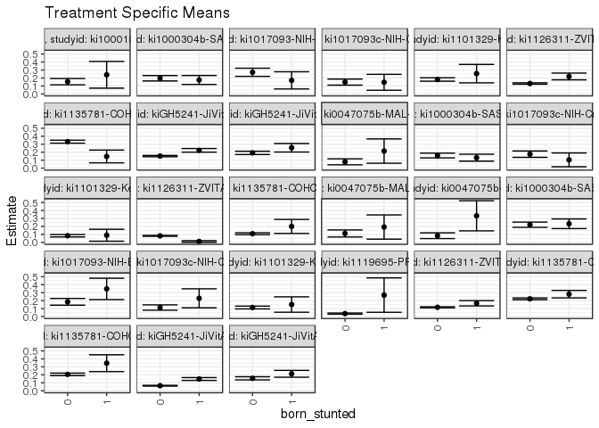

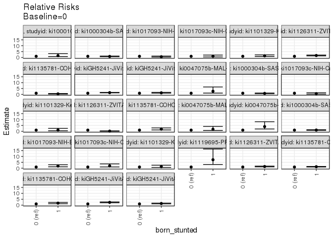

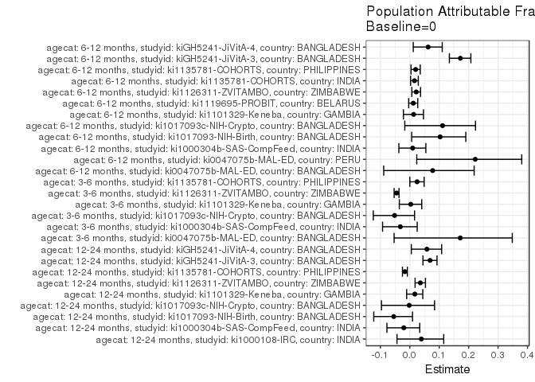

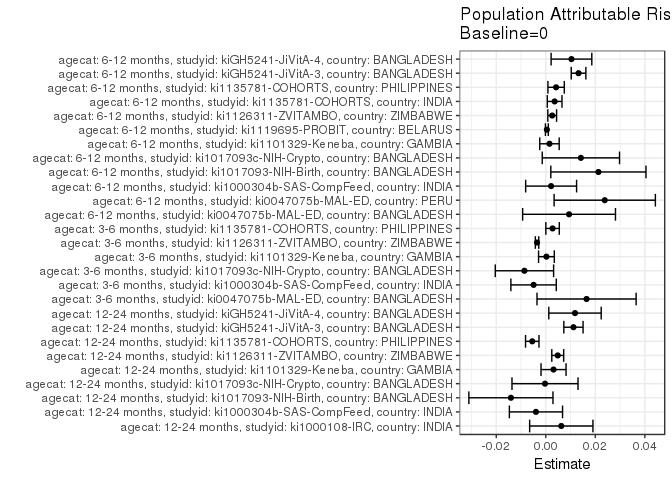

## Results Table

### Parameter: TSM

| agecat | studyid | country | intervention_level | baseline_level | estimate | ci_lower | ci_upper |
| --- | --- | --- | --- | --- | --- | --- | --- |
| 3-6 months | ki0047075b-MAL-ED | BANGLADESH | 0 | NA | 0.0796020 | 0.0421004 | 0.1171036 |
| 3-6 months | ki0047075b-MAL-ED | BANGLADESH | 1 | NA | 0.2142857 | 0.0619687 | 0.3666027 |
| 3-6 months | ki1000304b-SAS-CompFeed | INDIA | 0 | NA | 0.1582953 | 0.1285473 | 0.1880432 |
| 3-6 months | ki1000304b-SAS-CompFeed | INDIA | 1 | NA | 0.1310345 | 0.0876100 | 0.1744589 |
| 3-6 months | ki1017093c-NIH-Crypto | BANGLADESH | 0 | NA | 0.1752874 | 0.1352897 | 0.2152850 |
| 3-6 months | ki1017093c-NIH-Crypto | BANGLADESH | 1 | NA | 0.1041667 | 0.0176391 | 0.1906942 |
| 3-6 months | ki1101329-Keneba | GAMBIA | 0 | NA | 0.0830745 | 0.0679962 | 0.0981528 |
| 3-6 months | ki1101329-Keneba | GAMBIA | 1 | NA | 0.0892857 | 0.0145724 | 0.1639990 |
| 3-6 months | ki1126311-ZVITAMBO | ZIMBABWE | 0 | NA | 0.0817618 | 0.0757197 | 0.0878039 |
| 3-6 months | ki1126311-ZVITAMBO | ZIMBABWE | 1 | NA | 0.0119048 | 0.0015317 | 0.0222779 |
| 3-6 months | ki1135781-COHORTS | PHILIPPINES | 0 | NA | 0.1085781 | 0.0965897 | 0.1205664 |
| 3-6 months | ki1135781-COHORTS | PHILIPPINES | 1 | NA | 0.2000000 | 0.1123313 | 0.2876687 |
| 6-12 months | ki0047075b-MAL-ED | BANGLADESH | 0 | NA | 0.1116751 | 0.0675938 | 0.1557565 |
| 6-12 months | ki0047075b-MAL-ED | BANGLADESH | 1 | NA | 0.1923077 | 0.0404773 | 0.3441381 |
| 6-12 months | ki0047075b-MAL-ED | PERU | 0 | NA | 0.0833333 | 0.0473866 | 0.1192800 |
| 6-12 months | ki0047075b-MAL-ED | PERU | 1 | NA | 0.3333333 | 0.1443604 | 0.5223063 |
| 6-12 months | ki1000304b-SAS-CompFeed | INDIA | 0 | NA | 0.2213115 | 0.1885224 | 0.2541006 |
| 6-12 months | ki1000304b-SAS-CompFeed | INDIA | 1 | NA | 0.2331288 | 0.1725937 | 0.2936640 |
| 6-12 months | ki1017093-NIH-Birth | BANGLADESH | 0 | NA | 0.1851852 | 0.1428315 | 0.2275389 |
| 6-12 months | ki1017093-NIH-Birth | BANGLADESH | 1 | NA | 0.3469388 | 0.2134833 | 0.4803942 |
| 6-12 months | ki1017093c-NIH-Crypto | BANGLADESH | 0 | NA | 0.1133721 | 0.0798256 | 0.1469186 |
| 6-12 months | ki1017093c-NIH-Crypto | BANGLADESH | 1 | NA | 0.2291667 | 0.1101143 | 0.3482191 |
| 6-12 months | ki1101329-Keneba | GAMBIA | 0 | NA | 0.1136364 | 0.0962163 | 0.1310565 |
| 6-12 months | ki1101329-Keneba | GAMBIA | 1 | NA | 0.1509434 | 0.0545274 | 0.2473594 |
| 6-12 months | ki1119695-PROBIT | BELARUS | 0 | NA | 0.0373483 | 0.0298218 | 0.0448749 |
| 6-12 months | ki1119695-PROBIT | BELARUS | 1 | NA | 0.2692308 | 0.0535401 | 0.4849215 |
| 6-12 months | ki1126311-ZVITAMBO | ZIMBABWE | 0 | NA | 0.1165060 | 0.1098081 | 0.1232038 |
| 6-12 months | ki1126311-ZVITAMBO | ZIMBABWE | 1 | NA | 0.1666667 | 0.1333252 | 0.2000081 |
| 6-12 months | ki1135781-COHORTS | INDIA | 0 | NA | 0.2225497 | 0.2114831 | 0.2336164 |
| 6-12 months | ki1135781-COHORTS | INDIA | 1 | NA | 0.2812500 | 0.2342769 | 0.3282231 |
| 6-12 months | ki1135781-COHORTS | PHILIPPINES | 0 | NA | 0.2058130 | 0.1901058 | 0.2215203 |
| 6-12 months | ki1135781-COHORTS | PHILIPPINES | 1 | NA | 0.3461538 | 0.2405558 | 0.4517519 |
| 6-12 months | kiGH5241-JiVitA-3 | BANGLADESH | 0 | NA | 0.0638140 | 0.0584983 | 0.0691297 |
| 6-12 months | kiGH5241-JiVitA-3 | BANGLADESH | 1 | NA | 0.1479795 | 0.1300089 | 0.1659501 |
| 6-12 months | kiGH5241-JiVitA-4 | BANGLADESH | 0 | NA | 0.1563739 | 0.1366367 | 0.1761111 |
| 6-12 months | kiGH5241-JiVitA-4 | BANGLADESH | 1 | NA | 0.2131980 | 0.1702610 | 0.2561350 |
| 12-24 months | ki1000108-IRC | INDIA | 0 | NA | 0.1540881 | 0.1143492 | 0.1938269 |
| 12-24 months | ki1000108-IRC | INDIA | 1 | NA | 0.2400000 | 0.0723419 | 0.4076581 |
| 12-24 months | ki1000304b-SAS-CompFeed | INDIA | 0 | NA | 0.1966292 | 0.1626865 | 0.2305719 |
| 12-24 months | ki1000304b-SAS-CompFeed | INDIA | 1 | NA | 0.1750000 | 0.1188658 | 0.2311342 |
| 12-24 months | ki1017093-NIH-Birth | BANGLADESH | 0 | NA | 0.2714777 | 0.2203055 | 0.3226498 |
| 12-24 months | ki1017093-NIH-Birth | BANGLADESH | 1 | NA | 0.1702128 | 0.0626104 | 0.2778152 |
| 12-24 months | ki1017093c-NIH-Crypto | BANGLADESH | 0 | NA | 0.1483680 | 0.1103670 | 0.1863689 |
| 12-24 months | ki1017093c-NIH-Crypto | BANGLADESH | 1 | NA | 0.1458333 | 0.0458582 | 0.2458085 |
| 12-24 months | ki1101329-Keneba | GAMBIA | 0 | NA | 0.1810833 | 0.1596153 | 0.2025512 |
| 12-24 months | ki1101329-Keneba | GAMBIA | 1 | NA | 0.2545455 | 0.1393784 | 0.3697125 |
| 12-24 months | ki1126311-ZVITAMBO | ZIMBABWE | 0 | NA | 0.1304348 | 0.1221495 | 0.1387201 |
| 12-24 months | ki1126311-ZVITAMBO | ZIMBABWE | 1 | NA | 0.2191781 | 0.1767348 | 0.2616213 |
| 12-24 months | ki1135781-COHORTS | PHILIPPINES | 0 | NA | 0.3317113 | 0.3131247 | 0.3502978 |
| 12-24 months | ki1135781-COHORTS | PHILIPPINES | 1 | NA | 0.1466667 | 0.0665859 | 0.2267474 |
| 12-24 months | kiGH5241-JiVitA-3 | BANGLADESH | 0 | NA | 0.1512534 | 0.1427195 | 0.1597874 |
| 12-24 months | kiGH5241-JiVitA-3 | BANGLADESH | 1 | NA | 0.2232376 | 0.2005724 | 0.2459028 |
| 12-24 months | kiGH5241-JiVitA-4 | BANGLADESH | 0 | NA | 0.1914894 | 0.1708716 | 0.2121071 |
| 12-24 months | kiGH5241-JiVitA-4 | BANGLADESH | 1 | NA | 0.2557545 | 0.2023328 | 0.3091762 |

### Parameter: E(Y)

| agecat | studyid | country | intervention_level | baseline_level | estimate | ci_lower | ci_upper |
| --- | --- | --- | --- | --- | --- | --- | --- |
| 3-6 months | ki0047075b-MAL-ED | BANGLADESH | NA | NA | 0.0960699 | 0.0578190 | 0.1343208 |
| 3-6 months | ki1000304b-SAS-CompFeed | INDIA | NA | NA | 0.1533666 | 0.1270023 | 0.1797309 |
| 3-6 months | ki1017093c-NIH-Crypto | BANGLADESH | NA | NA | 0.1666667 | 0.1299145 | 0.2034189 |
| 3-6 months | ki1101329-Keneba | GAMBIA | NA | NA | 0.0833333 | 0.0685516 | 0.0981151 |
| 3-6 months | ki1126311-ZVITAMBO | ZIMBABWE | NA | NA | 0.0782358 | 0.0724655 | 0.0840061 |
| 3-6 months | ki1135781-COHORTS | PHILIPPINES | NA | NA | 0.1113193 | 0.0993824 | 0.1232563 |
| 6-12 months | ki0047075b-MAL-ED | BANGLADESH | NA | NA | 0.1210762 | 0.0781644 | 0.1639880 |
| 6-12 months | ki0047075b-MAL-ED | PERU | NA | NA | 0.1071429 | 0.0688794 | 0.1454063 |
| 6-12 months | ki1000304b-SAS-CompFeed | INDIA | NA | NA | 0.2234637 | 0.1907158 | 0.2562116 |
| 6-12 months | ki1017093-NIH-Birth | BANGLADESH | NA | NA | 0.2064343 | 0.1653043 | 0.2475643 |
| 6-12 months | ki1017093c-NIH-Crypto | BANGLADESH | NA | NA | 0.1275510 | 0.0944858 | 0.1606163 |
| 6-12 months | ki1101329-Keneba | GAMBIA | NA | NA | 0.1151242 | 0.0979580 | 0.1322903 |
| 6-12 months | ki1119695-PROBIT | BELARUS | NA | NA | 0.0377882 | 0.0302168 | 0.0453595 |
| 6-12 months | ki1126311-ZVITAMBO | ZIMBABWE | NA | NA | 0.1190963 | 0.1125112 | 0.1256814 |
| 6-12 months | ki1135781-COHORTS | INDIA | NA | NA | 0.2261246 | 0.2153393 | 0.2369098 |
| 6-12 months | ki1135781-COHORTS | PHILIPPINES | NA | NA | 0.2099848 | 0.1943978 | 0.2255717 |
| 6-12 months | kiGH5241-JiVitA-3 | BANGLADESH | NA | NA | 0.0770470 | 0.0716324 | 0.0824616 |
| 6-12 months | kiGH5241-JiVitA-4 | BANGLADESH | NA | NA | 0.1667439 | 0.1481671 | 0.1853207 |
| 12-24 months | ki1000108-IRC | INDIA | NA | NA | 0.1603499 | 0.1214616 | 0.1992381 |
| 12-24 months | ki1000304b-SAS-CompFeed | INDIA | NA | NA | 0.1926606 | 0.1608065 | 0.2245146 |
| 12-24 months | ki1017093-NIH-Birth | BANGLADESH | NA | NA | 0.2573964 | 0.2107184 | 0.3040745 |
| 12-24 months | ki1017093c-NIH-Crypto | BANGLADESH | NA | NA | 0.1480519 | 0.1125301 | 0.1835738 |
| 12-24 months | ki1101329-Keneba | GAMBIA | NA | NA | 0.1842105 | 0.1630644 | 0.2053567 |
| 12-24 months | ki1126311-ZVITAMBO | ZIMBABWE | NA | NA | 0.1352599 | 0.1270781 | 0.1434418 |
| 12-24 months | ki1135781-COHORTS | PHILIPPINES | NA | NA | 0.3262495 | 0.3080166 | 0.3444824 |
| 12-24 months | kiGH5241-JiVitA-3 | BANGLADESH | NA | NA | 0.1624278 | 0.1545118 | 0.1703438 |
| 12-24 months | kiGH5241-JiVitA-4 | BANGLADESH | NA | NA | 0.2032864 | 0.1839142 | 0.2226586 |

### Parameter: RR

| agecat | studyid | country | intervention_level | baseline_level | estimate | ci_lower | ci_upper |
| --- | --- | --- | --- | --- | --- | --- | --- |
| 3-6 months | ki0047075b-MAL-ED | BANGLADESH | 0 | 0 | 1.0000000 | 1.0000000 | 1.0000000 |
| 3-6 months | ki0047075b-MAL-ED | BANGLADESH | 1 | 0 | 2.6919643 | 1.1474121 | 6.3156661 |
| 3-6 months | ki1000304b-SAS-CompFeed | INDIA | 0 | 0 | 1.0000000 | 1.0000000 | 1.0000000 |
| 3-6 months | ki1000304b-SAS-CompFeed | INDIA | 1 | 0 | 0.8277851 | 0.5732900 | 1.1952559 |
| 3-6 months | ki1017093c-NIH-Crypto | BANGLADESH | 0 | 0 | 1.0000000 | 1.0000000 | 1.0000000 |
| 3-6 months | ki1017093c-NIH-Crypto | BANGLADESH | 1 | 0 | 0.5942623 | 0.2511085 | 1.4063549 |
| 3-6 months | ki1101329-Keneba | GAMBIA | 0 | 0 | 1.0000000 | 1.0000000 | 1.0000000 |
| 3-6 months | ki1101329-Keneba | GAMBIA | 1 | 0 | 1.0747664 | 0.4565105 | 2.5303312 |
| 3-6 months | ki1126311-ZVITAMBO | ZIMBABWE | 0 | 0 | 1.0000000 | 1.0000000 | 1.0000000 |
| 3-6 months | ki1126311-ZVITAMBO | ZIMBABWE | 1 | 0 | 0.1456035 | 0.0607289 | 0.3490984 |
| 3-6 months | ki1135781-COHORTS | PHILIPPINES | 0 | 0 | 1.0000000 | 1.0000000 | 1.0000000 |
| 3-6 months | ki1135781-COHORTS | PHILIPPINES | 1 | 0 | 1.8419929 | 1.1721185 | 2.8947053 |
| 6-12 months | ki0047075b-MAL-ED | BANGLADESH | 0 | 0 | 1.0000000 | 1.0000000 | 1.0000000 |
| 6-12 months | ki0047075b-MAL-ED | BANGLADESH | 1 | 0 | 1.7220280 | 0.7123459 | 4.1628377 |
| 6-12 months | ki0047075b-MAL-ED | PERU | 0 | 0 | 1.0000000 | 1.0000000 | 1.0000000 |
| 6-12 months | ki0047075b-MAL-ED | PERU | 1 | 0 | 4.0000000 | 1.9619245 | 8.1552579 |
| 6-12 months | ki1000304b-SAS-CompFeed | INDIA | 0 | 0 | 1.0000000 | 1.0000000 | 1.0000000 |
| 6-12 months | ki1000304b-SAS-CompFeed | INDIA | 1 | 0 | 1.0533970 | 0.8259327 | 1.3435055 |
| 6-12 months | ki1017093-NIH-Birth | BANGLADESH | 0 | 0 | 1.0000000 | 1.0000000 | 1.0000000 |
| 6-12 months | ki1017093-NIH-Birth | BANGLADESH | 1 | 0 | 1.8734694 | 1.1975407 | 2.9309131 |
| 6-12 months | ki1017093c-NIH-Crypto | BANGLADESH | 0 | 0 | 1.0000000 | 1.0000000 | 1.0000000 |
| 6-12 months | ki1017093c-NIH-Crypto | BANGLADESH | 1 | 0 | 2.0213675 | 1.1117263 | 3.6752991 |
| 6-12 months | ki1101329-Keneba | GAMBIA | 0 | 0 | 1.0000000 | 1.0000000 | 1.0000000 |
| 6-12 months | ki1101329-Keneba | GAMBIA | 1 | 0 | 1.3283019 | 0.6886707 | 2.5620168 |
| 6-12 months | ki1119695-PROBIT | BELARUS | 0 | 0 | 1.0000000 | 1.0000000 | 1.0000000 |
| 6-12 months | ki1119695-PROBIT | BELARUS | 1 | 0 | 7.2086407 | 3.1819925 | 16.3308055 |
| 6-12 months | ki1126311-ZVITAMBO | ZIMBABWE | 0 | 0 | 1.0000000 | 1.0000000 | 1.0000000 |
| 6-12 months | ki1126311-ZVITAMBO | ZIMBABWE | 1 | 0 | 1.4305420 | 1.1617273 | 1.7615584 |
| 6-12 months | ki1135781-COHORTS | INDIA | 0 | 0 | 1.0000000 | 1.0000000 | 1.0000000 |
| 6-12 months | ki1135781-COHORTS | INDIA | 1 | 0 | 1.2637624 | 1.0616584 | 1.5043403 |
| 6-12 months | ki1135781-COHORTS | PHILIPPINES | 0 | 0 | 1.0000000 | 1.0000000 | 1.0000000 |
| 6-12 months | ki1135781-COHORTS | PHILIPPINES | 1 | 0 | 1.6818849 | 1.2280808 | 2.3033801 |
| 6-12 months | kiGH5241-JiVitA-3 | BANGLADESH | 0 | 0 | 1.0000000 | 1.0000000 | 1.0000000 |
| 6-12 months | kiGH5241-JiVitA-3 | BANGLADESH | 1 | 0 | 2.3189202 | 2.0043146 | 2.6829076 |
| 6-12 months | kiGH5241-JiVitA-4 | BANGLADESH | 0 | 0 | 1.0000000 | 1.0000000 | 1.0000000 |
| 6-12 months | kiGH5241-JiVitA-4 | BANGLADESH | 1 | 0 | 1.3633856 | 1.0857062 | 1.7120840 |
| 12-24 months | ki1000108-IRC | INDIA | 0 | 0 | 1.0000000 | 1.0000000 | 1.0000000 |
| 12-24 months | ki1000108-IRC | INDIA | 1 | 0 | 1.5575510 | 0.7396743 | 3.2797747 |
| 12-24 months | ki1000304b-SAS-CompFeed | INDIA | 0 | 0 | 1.0000000 | 1.0000000 | 1.0000000 |
| 12-24 months | ki1000304b-SAS-CompFeed | INDIA | 1 | 0 | 0.8900000 | 0.6446229 | 1.2287804 |
| 12-24 months | ki1017093-NIH-Birth | BANGLADESH | 0 | 0 | 1.0000000 | 1.0000000 | 1.0000000 |
| 12-24 months | ki1017093-NIH-Birth | BANGLADESH | 1 | 0 | 0.6269863 | 0.3241663 | 1.2126855 |
| 12-24 months | ki1017093c-NIH-Crypto | BANGLADESH | 0 | 0 | 1.0000000 | 1.0000000 | 1.0000000 |
| 12-24 months | ki1017093c-NIH-Crypto | BANGLADESH | 1 | 0 | 0.9829167 | 0.4728118 | 2.0433611 |
| 12-24 months | ki1101329-Keneba | GAMBIA | 0 | 0 | 1.0000000 | 1.0000000 | 1.0000000 |
| 12-24 months | ki1101329-Keneba | GAMBIA | 1 | 0 | 1.4056818 | 0.8805631 | 2.2439521 |
| 12-24 months | ki1126311-ZVITAMBO | ZIMBABWE | 0 | 0 | 1.0000000 | 1.0000000 | 1.0000000 |
| 12-24 months | ki1126311-ZVITAMBO | ZIMBABWE | 1 | 0 | 1.6803653 | 1.3705496 | 2.0602154 |
| 12-24 months | ki1135781-COHORTS | PHILIPPINES | 0 | 0 | 1.0000000 | 1.0000000 | 1.0000000 |
| 12-24 months | ki1135781-COHORTS | PHILIPPINES | 1 | 0 | 0.4421516 | 0.2553871 | 0.7654970 |
| 12-24 months | kiGH5241-JiVitA-3 | BANGLADESH | 0 | 0 | 1.0000000 | 1.0000000 | 1.0000000 |
| 12-24 months | kiGH5241-JiVitA-3 | BANGLADESH | 1 | 0 | 1.4759174 | 1.3108510 | 1.6617694 |
| 12-24 months | kiGH5241-JiVitA-4 | BANGLADESH | 0 | 0 | 1.0000000 | 1.0000000 | 1.0000000 |
| 12-24 months | kiGH5241-JiVitA-4 | BANGLADESH | 1 | 0 | 1.3356067 | 1.0540284 | 1.6924073 |

### Parameter: PAR

| agecat | studyid | country | intervention_level | baseline_level | estimate | ci_lower | ci_upper |
| --- | --- | --- | --- | --- | --- | --- | --- |
| 3-6 months | ki0047075b-MAL-ED | BANGLADESH | 0 | NA | 0.0164679 | -0.0035490 | 0.0364848 |
| 3-6 months | ki1000304b-SAS-CompFeed | INDIA | 0 | NA | -0.0049287 | -0.0140987 | 0.0042413 |
| 3-6 months | ki1017093c-NIH-Crypto | BANGLADESH | 0 | NA | -0.0086207 | -0.0203998 | 0.0031584 |
| 3-6 months | ki1101329-Keneba | GAMBIA | 0 | NA | 0.0002588 | -0.0029177 | 0.0034353 |
| 3-6 months | ki1126311-ZVITAMBO | ZIMBABWE | 0 | NA | -0.0035260 | -0.0042153 | -0.0028367 |
| 3-6 months | ki1135781-COHORTS | PHILIPPINES | 0 | NA | 0.0027413 | 0.0000229 | 0.0054597 |
| 6-12 months | ki0047075b-MAL-ED | BANGLADESH | 0 | NA | 0.0094011 | -0.0093438 | 0.0281460 |
| 6-12 months | ki0047075b-MAL-ED | PERU | 0 | NA | 0.0238095 | 0.0033632 | 0.0442558 |
| 6-12 months | ki1000304b-SAS-CompFeed | INDIA | 0 | NA | 0.0021522 | -0.0081344 | 0.0124388 |
| 6-12 months | ki1017093-NIH-Birth | BANGLADESH | 0 | NA | 0.0212491 | 0.0020359 | 0.0404623 |
| 6-12 months | ki1017093c-NIH-Crypto | BANGLADESH | 0 | NA | 0.0141789 | -0.0014269 | 0.0297848 |
| 6-12 months | ki1101329-Keneba | GAMBIA | 0 | NA | 0.0014878 | -0.0024392 | 0.0054148 |
| 6-12 months | ki1119695-PROBIT | BELARUS | 0 | NA | 0.0004398 | -0.0001460 | 0.0010256 |
| 6-12 months | ki1126311-ZVITAMBO | ZIMBABWE | 0 | NA | 0.0025903 | 0.0008197 | 0.0043609 |
| 6-12 months | ki1135781-COHORTS | INDIA | 0 | NA | 0.0035748 | 0.0006137 | 0.0065360 |
| 6-12 months | ki1135781-COHORTS | PHILIPPINES | 0 | NA | 0.0041717 | 0.0008697 | 0.0074737 |
| 6-12 months | kiGH5241-JiVitA-3 | BANGLADESH | 0 | NA | 0.0132330 | 0.0102787 | 0.0161873 |
| 6-12 months | kiGH5241-JiVitA-4 | BANGLADESH | 0 | NA | 0.0103699 | 0.0021538 | 0.0185860 |
| 12-24 months | ki1000108-IRC | INDIA | 0 | NA | 0.0062618 | -0.0065178 | 0.0190414 |
| 12-24 months | ki1000304b-SAS-CompFeed | INDIA | 0 | NA | -0.0039687 | -0.0147083 | 0.0067710 |
| 12-24 months | ki1017093-NIH-Birth | BANGLADESH | 0 | NA | -0.0140812 | -0.0310666 | 0.0029041 |
| 12-24 months | ki1017093c-NIH-Crypto | BANGLADESH | 0 | NA | -0.0003160 | -0.0136508 | 0.0130187 |
| 12-24 months | ki1101329-Keneba | GAMBIA | 0 | NA | 0.0031273 | -0.0019250 | 0.0081795 |
| 12-24 months | ki1126311-ZVITAMBO | ZIMBABWE | 0 | NA | 0.0048252 | 0.0024251 | 0.0072252 |
| 12-24 months | ki1135781-COHORTS | PHILIPPINES | 0 | NA | -0.0054618 | -0.0081768 | -0.0027468 |
| 12-24 months | kiGH5241-JiVitA-3 | BANGLADESH | 0 | NA | 0.0111744 | 0.0072916 | 0.0150572 |
| 12-24 months | kiGH5241-JiVitA-4 | BANGLADESH | 0 | NA | 0.0117970 | 0.0012124 | 0.0223816 |

### Parameter: PAF

| agecat | studyid | country | intervention_level | baseline_level | estimate | ci_lower | ci_upper |
| --- | --- | --- | --- | --- | --- | --- | --- |
| 3-6 months | ki0047075b-MAL-ED | BANGLADESH | 0 | NA | 0.1714156 | -0.0534323 | 0.3482713 |
| 3-6 months | ki1000304b-SAS-CompFeed | INDIA | 0 | NA | -0.0321367 | -0.0926763 | 0.0250487 |
| 3-6 months | ki1017093c-NIH-Crypto | BANGLADESH | 0 | NA | -0.0517241 | -0.1242551 | 0.0161276 |
| 3-6 months | ki1101329-Keneba | GAMBIA | 0 | NA | 0.0031056 | -0.0357473 | 0.0405010 |
| 3-6 months | ki1126311-ZVITAMBO | ZIMBABWE | 0 | NA | -0.0450690 | -0.0533805 | -0.0368231 |
| 3-6 months | ki1135781-COHORTS | PHILIPPINES | 0 | NA | 0.0246254 | 0.0000082 | 0.0486366 |
| 6-12 months | ki0047075b-MAL-ED | BANGLADESH | 0 | NA | 0.0776462 | -0.0887560 | 0.2186160 |
| 6-12 months | ki0047075b-MAL-ED | PERU | 0 | NA | 0.2222222 | 0.0235864 | 0.3804487 |
| 6-12 months | ki1000304b-SAS-CompFeed | INDIA | 0 | NA | 0.0096311 | -0.0372841 | 0.0544245 |
| 6-12 months | ki1017093-NIH-Birth | BANGLADESH | 0 | NA | 0.1029341 | 0.0062073 | 0.1902464 |
| 6-12 months | ki1017093c-NIH-Crypto | BANGLADESH | 0 | NA | 0.1111628 | -0.0170996 | 0.2232505 |
| 6-12 months | ki1101329-Keneba | GAMBIA | 0 | NA | 0.0129234 | -0.0217417 | 0.0464123 |
| 6-12 months | ki1119695-PROBIT | BELARUS | 0 | NA | 0.0116389 | -0.0038918 | 0.0269293 |
| 6-12 months | ki1126311-ZVITAMBO | ZIMBABWE | 0 | NA | 0.0217499 | 0.0068056 | 0.0364693 |
| 6-12 months | ki1135781-COHORTS | INDIA | 0 | NA | 0.0158091 | 0.0026356 | 0.0288086 |
| 6-12 months | ki1135781-COHORTS | PHILIPPINES | 0 | NA | 0.0198668 | 0.0040488 | 0.0354335 |
| 6-12 months | kiGH5241-JiVitA-3 | BANGLADESH | 0 | NA | 0.1717524 | 0.1344292 | 0.2074663 |
| 6-12 months | kiGH5241-JiVitA-4 | BANGLADESH | 0 | NA | 0.0621907 | 0.0116374 | 0.1101584 |
| 12-24 months | ki1000108-IRC | INDIA | 0 | NA | 0.0390509 | -0.0436581 | 0.1152053 |
| 12-24 months | ki1000304b-SAS-CompFeed | INDIA | 0 | NA | -0.0205993 | -0.0778875 | 0.0336442 |
| 12-24 months | ki1017093-NIH-Birth | BANGLADESH | 0 | NA | -0.0547063 | -0.1225897 | 0.0090721 |
| 12-24 months | ki1017093c-NIH-Crypto | BANGLADESH | 0 | NA | -0.0021344 | -0.0963729 | 0.0840039 |
| 12-24 months | ki1101329-Keneba | GAMBIA | 0 | NA | 0.0169766 | -0.0107966 | 0.0439866 |
| 12-24 months | ki1126311-ZVITAMBO | ZIMBABWE | 0 | NA | 0.0356732 | 0.0178585 | 0.0531649 |
| 12-24 months | ki1135781-COHORTS | PHILIPPINES | 0 | NA | -0.0167411 | -0.0250963 | -0.0084540 |
| 12-24 months | kiGH5241-JiVitA-3 | BANGLADESH | 0 | NA | 0.0687958 | 0.0446152 | 0.0923644 |
| 12-24 months | kiGH5241-JiVitA-4 | BANGLADESH | 0 | NA | 0.0580315 | 0.0050776 | 0.1081671 |